# Labo 9

Ahora graficamos nuestros resultados. Un agrupamiento creado con agnes genera dos gráficos, el primero muestra cómo se obtuvieron los grupos finales y el segundo es un dendrograma. Pediremos el segundo gráfico (which.plots = 2).

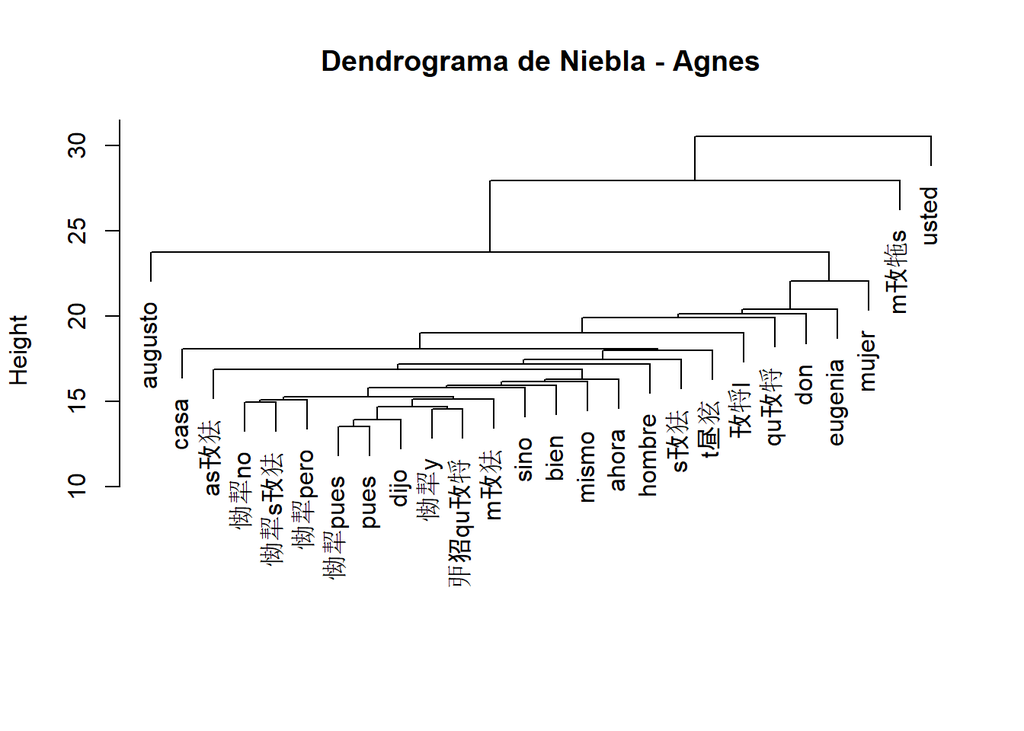

```r
plot(nov_agnes, which.plots = 2, main = "Dendrograma de Niebla - Agnes", sub = "", xlab = "")
```

Enfatizamos diez grupos.

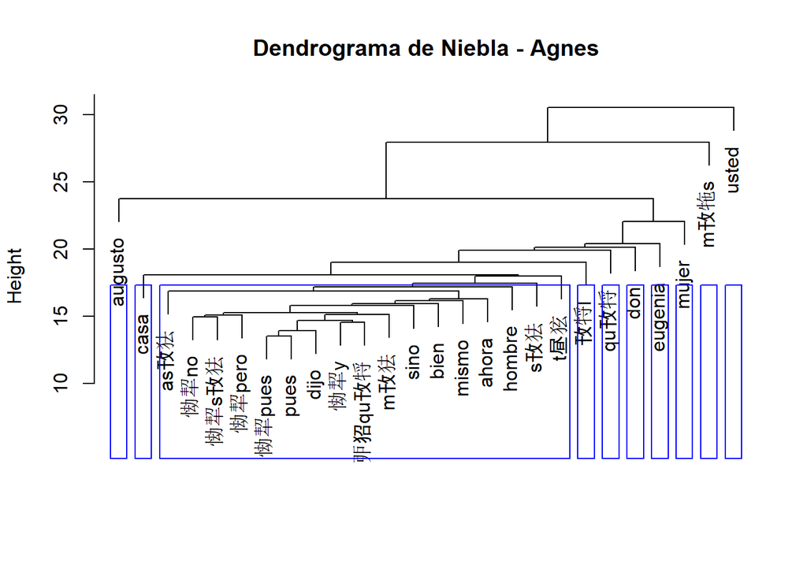

```r
plot(nov_agnes, which.plots = 2, main = "Dendrograma de Niebla - Agnes", sub = "", xlab = "")
rect.hclust(nov_agnes, k = 10, border = "blue")
```

Las agrupaciones que hemos obtenido usando hclust y agnes son diferentes entre sí. La decisión de qué método usemos depende de nuestros propósitos y de nuestra familiaridad con ellos.

### Regresion LOESS

A la hora de analizar las posibles tendencias de los sentimientos que utilizan puntajes, se podría aplicar un regresión LOESS para ver por donde anda la puntuación media en el tiempo.

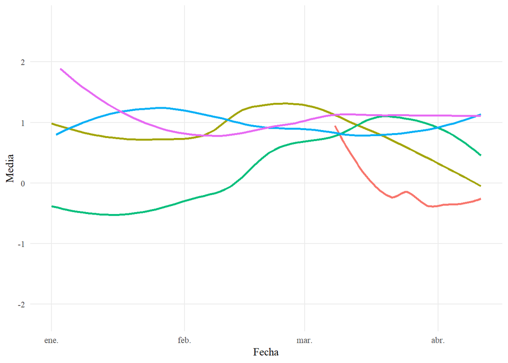

```r
tuits_afinn_fecha %>%
  ggplot() +
  aes(Fecha, Media, color = Candidato) +
  geom_smooth(method = "loess", fill = NA) +
  tema_graf
```

En realidad, podemos obtener líneas muy similares directamente de las puntuaciones.

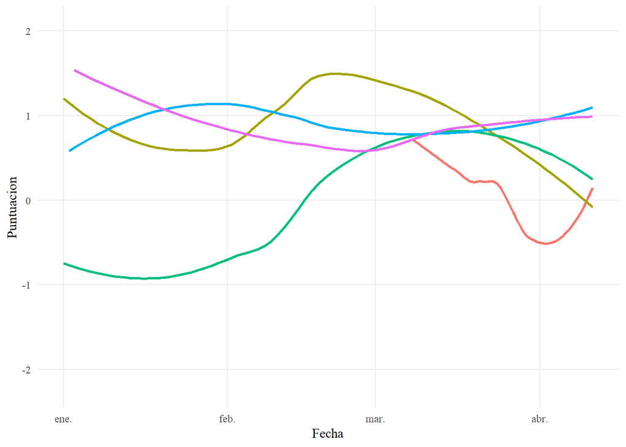

```r
tuits_afinn %>%
  ggplot() +
  aes(Fecha, Puntuacion, color = Candidato) +
  geom_smooth(method = "loess", fill = NA) +
  tema_graf
```

Si separamos las lineas por candidato y mostramos los puntos a partir de los cuales se obtienen las líneas de regresión, podemos observar con más claridad la manera en que el algoritmo LOESS llega a sus resultado. Haremos esto con facet_wrap() y geom_point.

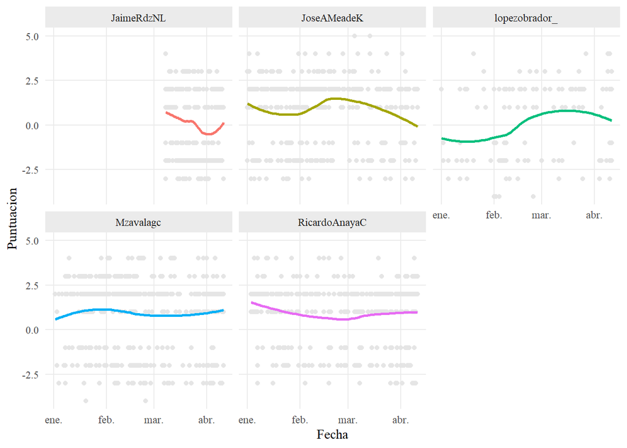

```r
tuits_afinn %>%
  ggplot() +
  aes(Fecha, Puntuacion, color = Candidato) +
  geom_point(color = "#E5E5E5") +
  geom_smooth(method = "loess", fill = NA) +
  facet_wrap(~Candidato) +
  tema_graf
```

### Media móvil

Creo que una forma más acertada es utilizando medias móviles. Corrige el ruido y aporta una mejor interpretación.

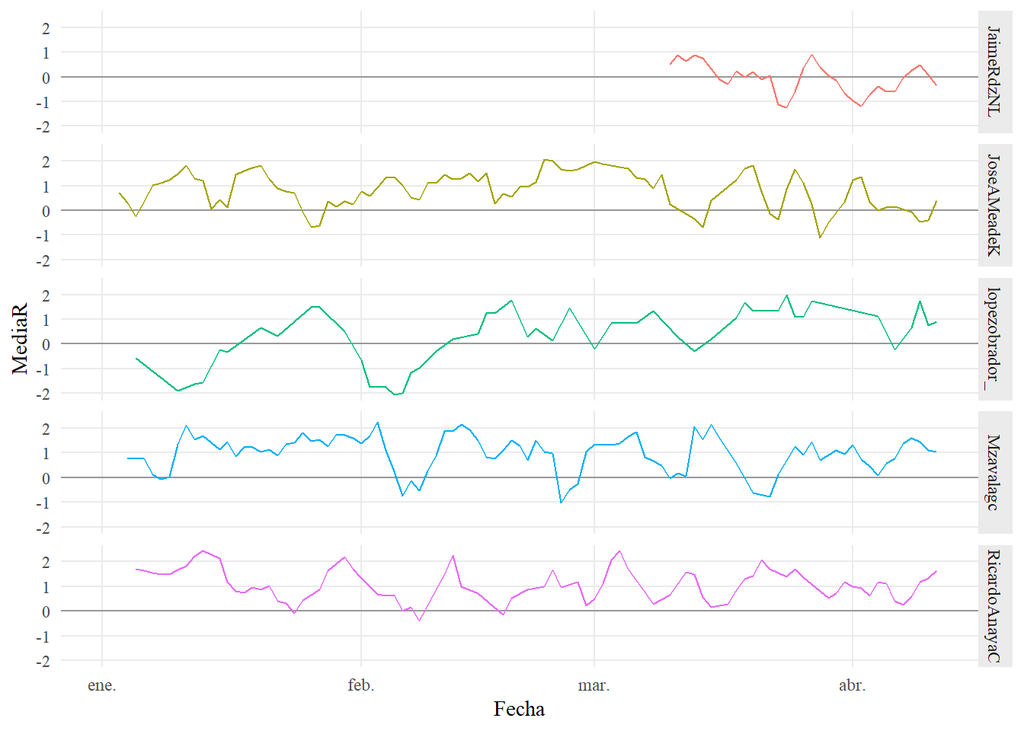

```r
tuits_afinn_fecha %>%
  group_by(Candidato) %>%
  mutate(MediaR = rollmean(Media, k = 3, align = "right", na.pad = TRUE)) %>%
  ggplot() +
  aes(Fecha, MediaR, color = Candidato) +
  geom_hline(yintercept = 0, alpha = .35) +
  geom_line() +
  facet_grid(Candidato~.) +
  tema_graf
```

## Web scraping

### Sitio para hacer web scraping

Los siguientes sitios son excelentes guías para aprender sobre el Web Scrapping.

https://www.datacamp.com/community/tutorials/r-web-scraping-rvest

https://rpubs.com/jboscomendoza/coheed_and_cambria

### Ejemplo de extracción de elementos

¿Cómo extraemos los elemetos de un sito web? El siguiente ejemplo es excelente:

https://www.analyticsvidhya.com/blog/2017/03/beginners-guide-on-web-scraping-in-r-using-rvest-with-hands-on-knowledge/

### Elementos de un discos de música

Usamos la función read_html() de rvest, que lee el código html de una página web, a partir de su URL. Asignaremos al objeto musicbrainz_html el resultado de leer el código HTML de la página en la que se encuentran los metadatos del disco “The Afterman: Descencion”.

```r
musicbrainz_html <- read_html("https://musicbrainz.org/release/5e5dad52-a3cf-4cf7-a222-6f4bca6b17ef")
```

### ¿Cómo extraemos los datos d Tweeter?

El siguiente enlace lo explica, pero esperar que los de Tweeter les den los permisos, es a veces complicado….

https://cran.r-project.org/web/packages/rtweet/vignettes/auth.html